# ESM 204 Homework 3

Justine Lang

2023-05-18

```r
### Read in data

ev_dat <- read_csv(here("HW3_data.csv")) %>%
  clean_names() %>%
  rename("price" = "price_dollars",
         "dac" = "q_dac",
         "non_dac" = "q_non_dac")

ev_long <- ev_dat %>%
  pivot_longer(cols = dac:non_dac, names_to = "community", values_to = "quantity")
```

## Question 1

The data set HW3 data.csv provides price (in $) and quantity (in number of EVs) estimates of demand per year for both DAC and non-DAC groups. Run linear regressions (with an intercept) to estimate the demand curves for DAC and non-DAC consumers. What are 2-3 reasons you can think that may explain the differences in demand you estimate?

```r
### Run linear regressions

dac_lm <- lm(price ~ dac, data = ev_dat)
dac_coeff <- dac_lm$coefficients

non_dac_lm <- lm(price ~ non_dac, data = ev_dat)
non_dac_coeff <- non_dac_lm$coefficients
```

```r
### Write demand functions

### P = a + bQ

dac_demand <- function(Q){
  P = 116854.84 - 6.61*Q
  return(P)
}

nondac_demand <- function(Q){
  P =  158034.28 - 2.73*Q
  return(P)
}

### Q = (P - a)/b

dac_demand_q <- function(P){
  Q = (116854.84 - P)/6.61
  return(Q)
}

nondac_demand_q <- function(P){
  Q = (158034.28 - P)/2.73
  return(Q)
}
```

**DAC Demand:** $P = 116,854.84 - 6.61*Q$

**Non-DAC Demand:** $P = 158,034.28 - 2.73*Q$

Non-DAC communities have higher demand for EVs than DAC communities. This may be because non-DAC communities have higher income and might also have infrastructure that is better developed to support EV charging stations, two reasons that could contribute to that higher demand.

## Question 2

One kilogram (kg) of lithium is estimated to cause $300 dollars worth of damage in health costs to local communities living near mines. Each EV requires a lithium ion battery containing 63kg of lithium. Assuming there are no other externalities caused by EV production, what is the marginal externality cost per EV produced?

```r
MEC <- 300 * 63
```

$MEC = 18,900$

## Question 3

What is the aggregate annual demand curve for EVs? What is the supply curve for EVs? What is the “benefit” to consumers under the status quo? What is the “benefit” to producers under the status quo? What is the environmental cost under the status quo?

```r
### Write aggregate demand function

agg_demand <- function(P) {
  if (P > 116854.84) {
  Q = nondac_demand_q(P)
  }
  if(P <= 116854.84) {
   Q = dac_demand_q(P) + nondac_demand_q(P)
  }
  return(Q)
}
```

```r
### Supply = 0 + mQ
### EV price without intervention is $50,000 per EV

# agg_demand(50000) ### Q = 49687.19

# 50000/agg_demand(50000) ### 1.006296

supply <- function(Q) {
  P = 0 + 1.006296*Q
  return(P)
}
```

```r
### Surplus

cs_fun <- function(a, Q) {
  P = 1/2*(a - 50000)*Q
  return(P)
}

dac_cs <- cs_fun(116854.84, dac_demand_q(50000))
nondac_cs <- cs_fun(158034.28, nondac_demand_q(50000))
cs <- cs_fun(116854.84, dac_demand_q(50000)) + cs_fun(158034.28, nondac_demand_q(50000))

### DAC cs: 338091500
### Non-DAC cs: 2137620083
### total cs: 2475711583

ps_fun <- function(Q) {
  P = 1/2*50000*Q
  return(P)
}

# ps_fun(agg_demand(50000)) ### 1242179825
```

```r
### EC = Qagg * MEC

### Should have done this sooner
pstar <- 50000
qstar <- agg_demand(50000)

ec <- qstar*MEC
# ec ### 939087948
```

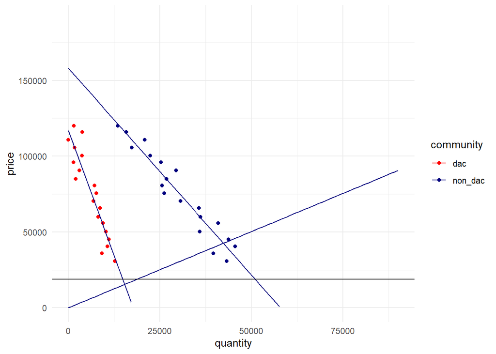

Figure 1: EV market supply and demand curves at the status quo for DAC and non-DAC communities. The horizontal black line is the MEC.

```r
### Visualize demand curves

ggplot(data = ev_long, aes(x = quantity, y = price, color = community)) +
  geom_point() +
  ylim(0, 190000) +
  xlim(0, 90000) +
  stat_function(fun = function(Q) dac_demand(Q)) +
  stat_function(fun = function(Q) nondac_demand(Q)) +
  stat_function(fun = function(Q) supply(Q)) +
  scale_color_manual(values = c('red', 'navy')) +
  geom_hline(yintercept = 18900) +
  theme_minimal()
```

**Aggregate Demand:** When P > 116,854.84, the aggregate demand curve is $P = 158,034.28 - 2.73*Q$. When P ≤ 116,854.84, the aggregate demand curve would be around $P = 145,997.96 - Q/0.5175$.

**Supply:** $P = 1.006*Q$

**Consumer Surplus:** $2,475,711,583

**Producer Surplus:** $1,242,179,825

**Environmental Cost:** $939,087,948

## Question 4

How is the current consumer benefit divided between DAC and non-DAC consumers?

**DAC CS:** $338,091,500, or 14% of the consumer benefit.

**Non-DAC CS:** $2,137,620,083, or 86% of the consumer benefit.

```r
### Percentages

dac_perc <- dac_cs/cs
nondac_perc <- nondac_cs/cs

# dac_perc ### 0.1365634
# nondac_perc ### 0.8634366
```

## Question 5

Derive the optimal EV tax (in $ per vehicle) to internalize the lithium mining externality. Noting that recent research has shown that DACs are far more likely to contain mining activity, assume that the mining externality is borne entirely by the DAC group. What would be the effects of this tax on:

**(a) The amount of EVs produced and consumed**

```r
### New socially optimal supply curve with MEC

msc <- function(Q) {
  P = MEC + 1.006296*Q
  return(P)
}

msc_q <- function(P) {
  Q = (P - MEC)/1.006296
  return(Q)
}
```

The optimal tax is the MEC at the socially optimal Q. Since the MEC is constant, the optimal tax is $18,900.

```r
agg_demand_p <- function(Q){
  P = (75566.5 - Q)/0.5175
  return(P)
}


F3 <- function(Q){
  z <- agg_demand_p(Q) - msc(Q)
  return(z)
  }
```

```r
# fzero(F3, c(0,1000))$x

qstar_so <- 43258.5

# agg_demand(50000)
```

The socially optimal quantity is around 43,258.5 EVs, which could be rounded down to 43,258. This is less than the previous Qstar of 49,687 EVs.

**(b) The price of EVs**

```r
pstar_so <- msc(qstar_so) ### 62430.86
```

The socially optimal price is around $62,430.86, which is higher than the previous Pstar of $50,000.

**(c) Overall welfare of non-DAC consumers**

```r
### Writing more general CS and PS functions

cs_fun2 <- function(a, Popt, Q) {
  P = 1/2*(a - Popt)*Q
  return(P)
}

ps_fun2 <- function(Popt, Q) {
  P = 1/2*Popt*Q
  return(P)
}
```

```r
# cs_fun2(158034.28, pstar_so, nondac_demand_q(pstar_so)) ### 1673995380
```

Non-DAC CS: $1,673,995,380, which is lower than the previous CS of $2,137,620,083.

**(d) Overall welfare of DAC consumers**

```r
# cs_fun2(116854.84, pstar_so, dac_demand_q(pstar_so)) ### 224052200

# 224052200 - 817484583 ### -593432383
```

DAC CS: $224,052,200, which is lower than the previous CS of $338,091,500. If you subtract all of the environmental costs from that number, the overall welfare is a loss of -$593,432,383.

**(e) EV producers**

```r
# ps_fun2(pstar_so, agg_demand(pstar_so)) ### 1350165658
```

PS: $1,350,165,658, which is higher than the previous PS of $1,242,179,825.

**(f) Total environmental damage**

```r
ec_t <- agg_demand(pstar_so) * MEC ### 817484583
```

Total environmental damage: $817,484,583, which is lower than the previous $939,087,948

**(g) Total tax revenue generated**

Total tax revenue is the same as total environmental damage: $817,484,583.

## Question 6

Now, assume that all revenue from the EV tax will be redistributed to the consumers in proportion to their pre-tax consumption. For example, if 80% of the EVs were consumed by non-DAC consumers, then they get 80% of the tax revenue. Additionally, consider that emerging scientific evidence suggests the true environmental damages from lithium mining may be much higher than $300. For a range of values of external costs per kg of lithium ($350, $400, $450, and $500 per kg), calculate the effects of an EV tax on: (a) Overall welfare of non-DAC consumers (b) Overall welfare of DAC consumers (c) EV producers

```r
### Write MEC function

mec_fun <- function(dam) {
   P = dam * 63
   return(P)
}

mec_350 <- mec_fun(350)
mec_400 <- mec_fun(400)
mec_450 <- mec_fun(450)
mec_500 <- mec_fun(500)
```

```r
### New supply curves

msc2 <- function(dam, Q) {
  P = mec_fun(dam) + 1.006296*Q
  return(P)
}
```

```r
### Let's try Sandy's method

supply_tax <- function(p, tax) {
  (p - tax)/1.006296
}

equi_p <- function(p) {
  agg_demand(p) - supply_tax(p, mec_fun(300))
}

p_star1 <- uniroot(equi_p, c(-100000, 100000))$root ### Success
```

```r
### Pstar 350

equi_p350 <- function(p) {
  agg_demand(p) - supply_tax(p, mec_fun(350))
}
pstar_350 <- uniroot(equi_p350, c(-100000, 100000))$root

### Pstar 400

equi_p400 <- function(p) {
  agg_demand(p) - supply_tax(p, mec_fun(400))
}
pstar_400 <- uniroot(equi_p400, c(-100000, 100000))$root

### Pstar 450

equi_p450 <- function(p) {
  agg_demand(p) - supply_tax(p, mec_fun(450))
}
pstar_450 <- uniroot(equi_p450, c(-100000, 100000))$root

### Pstar 500

equi_p500 <- function(p) {
  agg_demand(p) - supply_tax(p, mec_fun(500))
}
pstar_500 <- uniroot(equi_p500, c(-100000, 100000))$root
```

```r
### Qstar 350

qstar_350 <- agg_demand(pstar_350)

### Qstar 400

qstar_400 <- agg_demand(pstar_400)

### Qstar 450

qstar_450 <- agg_demand(pstar_450)

### Qstar 500

qstar_500 <- agg_demand(pstar_500)
```

```r
### Tax revenue

rev_350 <- agg_demand(pstar_350) * mec_350
rev_400 <- agg_demand(pstar_400) * mec_400
rev_450 <- agg_demand(pstar_450) * mec_450
rev_500 <- agg_demand(pstar_500) * mec_500

### Shares

dac_shares <- function(rev) {
  rev * dac_perc
}

nondac_shares <- function(rev) {
  rev * nondac_perc
}

dac_350 <- dac_shares(rev_350)
dac_400 <- dac_shares(rev_400)
dac_450 <- dac_shares(rev_450)
dac_500 <- dac_shares(rev_500)

nondac_350 <- nondac_shares(rev_350)
nondac_400 <- nondac_shares(rev_400)
nondac_450 <- nondac_shares(rev_450)
nondac_500 <- nondac_shares(rev_500)
```

**(a) Overall welfare of non-DAC consumers**

```r
# cs_fun2(158034.28, pstar_350, nondac_demand_q(pstar_350)) + nondac_350
# cs_fun2(158034.28, pstar_400, nondac_demand_q(pstar_400)) + nondac_400
# cs_fun2(158034.28, pstar_450, nondac_demand_q(pstar_450)) + nondac_450
# cs_fun2(158034.28, pstar_500, nondac_demand_q(pstar_500)) + nondac_500
```

350: $2,405,481,004

400: $2,426,706,611

450: $2,443,672,137

500: $2,456,377,581

**(b) Overall welfare of DAC consumers**

```r
# cs_fun2(116854.84, pstar_350, dac_demand_q(pstar_350)) + dac_350 - rev_350
# cs_fun2(116854.84, pstar_400, dac_demand_q(pstar_400)) + dac_400 - rev_400
# cs_fun2(116854.84, pstar_450, dac_demand_q(pstar_450)) + dac_450 - rev_450
# cs_fun2(116854.84, pstar_500, dac_demand_q(pstar_500)) + dac_500 - rev_500
```

If the DAC consumers didn’t bear the externality, their surplus would be under each scenario:

350: $334,373,427

400: $332,749,033

450: $330,851,324

500: $328,680,299

But with the environmental damages considered:

350: -$595,760,629

400: -$703,246,072

450: -$804,251,019

500: -$898,775,470

**(c) EV producers**

```r
# ps_fun2(pstar_350, agg_demand(pstar_350))
# ps_fun2(pstar_400, agg_demand(pstar_400))
# ps_fun2(pstar_450, agg_demand(pstar_450))
# ps_fun2(pstar_500, agg_demand(pstar_500))
```

350: $1,360,369,234

400: $1,368,371,753

450: $1,374,153,858

500: $1,377,715,549

## Question 7

Now, consider the fact that the purchase of EVs not only leads to lithium mining, but also helps mitigate climate change by replacing gasoline cars. Suppose that climate change damages fall mostly outside California, to a lesser extent on DAC consumers, and not at all on non-DAC consumers. Qualitatively answer the following (in 1-3 sentences each):

**(a) How does the presence of climate change damages from gasoline cars affect the optimal EV tax in California?**

Since climate change damages at least partially fall on DAC consumers, they could lower the optimal EV tax slightly, since there would be a social benefit from purchasing EVs instead of gasoline cars, offsetting some of the impacts of climate change.

**(b) Assuming tax revenue does not get returned to consumers, are non-DAC consumers more or less likely to support this new tax, relative to the tax that only accounts for the mining externality? Why?**

If the EV tax is lowered, non-DAC consumers would be likely to support it since they have the higher demand for EVs and do not suffer any damage from the mining externality or climate change in this scenario.

**(c) Assuming tax revenue does not get returned to consumers, are DAC consumers more or less likely to support this new tax, relative to the tax that only accounts for the mining externality? Why?**

DAC consumers are less likely to support this new tax, especially if tax revenue does not get returned to consumers. They experience far more harm from lithium mining and climate change than non-DAC consumers despite having lower demand for EVs. They don’t really benefit from this tax.